# Blouch Ruminants Prediction

Data Prep

```r
rm(list=ls())
# Load necessary packages
library(ape)
library(slouch)
library(rstan)
library(treeplyr)

#For execution on a local, multicore CPU with excess RAM we recommend calling
#options(mc.cores = parallel::detectCores())
options(mc.cores = 2)
rstan_options(auto_write = TRUE)

#remotes::install_github("stan-dev/rstan", ref = "develop", subdir = "rstan/rstan")
```

For the purposes of illustrating the software, we will use a dataset of ruminant neocortices bundled with the Slouch package and a corresponding phylogenetic tree (Toljagić et al. 2017). First, we will organize the neocortex data and associated annotation data.

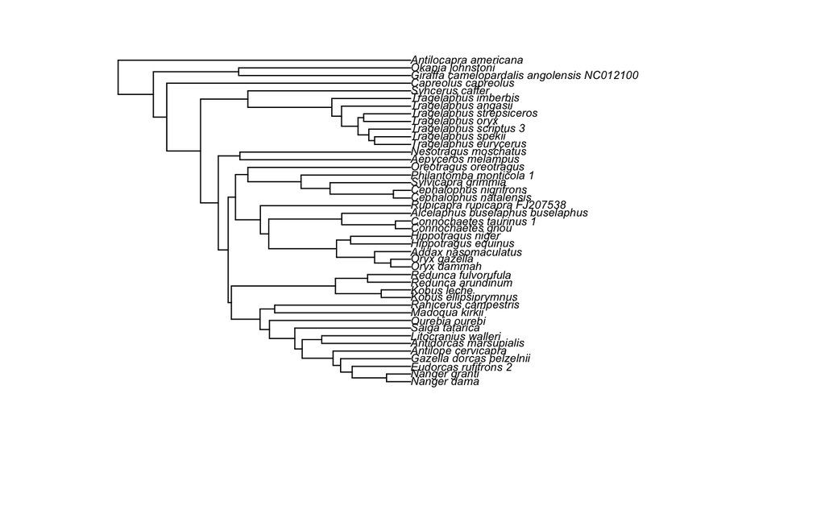

```r
## Load the phylogenetic tree with annotation data
data(artiodactyla)
phy <- artiodactyla

## Load the neocortex dataset
data(neocortex)

## Plot the tree
plot(ladderize(phy), cex = 0.6)
```

# Data Prep

Here we will assign one taxa as the fossil species to be predicted, and use Classical Regression to predict an unknown value based on the combination of phylogeny and allometry. Here we are regression Y - brain size on X body size, and then predicting a fossil X based on its Y.

```r
ruminant.trdata <- make.treedata(phy, neocortex,name_column="species")

ruminant.trdata<-filter(ruminant.trdata,!(is.na(brain_mass_g_log_mean)) & !(is.na(body_mass_g_log_mean)))
ruminant.trdata<-filter(ruminant.trdata,!(is.na(brain_se_squared)) & !(is.na(body_se_squared)))

ruminant.trdata #Full dataset
```

```
$phy

Phylogenetic tree with 43 tips and 42 internal nodes.

Tip labels:
  Antilocapra_americana, Addax_nasomaculatus, Aepyceros_melampus, Alcelaphus_buselaphus_buselaphus, Antidorcas_marsupialis, Antilope_cervicapra, ...
Node labels:
  MF, MF, MF, MF, MF, MF, ...

Rooted; includes branch lengths.

$dat
```

| brain_mass_g_log_mean | brain_se_squared | n_brain | body_mass_g_log_mean | body_se_squared | n_body | neocortex_area_mm2_log_mean | neocortex_se_squared | n_neocortex | diet |
| --- | --- | --- | --- | --- | --- | --- | --- | --- | --- |
| 4.795791 | 0.0109399018 | 1 | 10.985293 | 0.042611489 | 1 | 9.724565 | 0.0054186866 | 2 | MF |
| 5.302425 | 0.0054699509 | 2 | 11.637916 | 0.021305745 | 2 | 9.969274 | 0.0036124577 | 3 | MF |
| 5.152387 | 0.0009945365 | 11 | 10.947994 | 0.003873772 | 11 | 9.957203 | 0.0004926079 | 22 | MF |
| 5.693832 | 0.0021879804 | 5 | 11.879786 | 0.008522298 | 5 | 10.276531 | 0.0010837373 | 10 | Gr |
| 4.912034 | 0.0008415309 | 13 | 10.484431 | 0.003277807 | 13 | 9.720171 | 0.0008336441 | 13 | MF |
| 4.770685 | 0.0109399018 | 1 | 10.419301 | 0.042611489 | 1 | 9.615605 | 0.0054186866 | 2 | MF |
| 4.418841 | 0.0109399018 | 1 | 9.433484 | 0.042611489 | 1 | 8.836783 | 0.0054186866 | 2 | Br |
| 4.418204 | 0.0036466339 | 3 | 9.581309 | 0.021305745 | 2 | 8.892092 | 0.0018062289 | 6 | Br |
| 3.520064 | 0.0013674877 | 8 | 8.461336 | 0.005326436 | 8 | 8.277107 | 0.0006773358 | 16 | Br |
| 5.720312 | 0.0109399018 | 1 | 11.918391 | 0.042611489 | 1 | 10.264616 | 0.0054186866 | 2 | Gr |

[output cut: 33 more lines]

```r
ruminant.trdata$dat$Status<-"Extant" #Label all species as extant
ruminant.trdata$dat$Status[1]<-"Extinct" #Make one extinct
n.fos<-1

#Classical Regression - Predicting X using regression of Y on X
ruminant.trdata$dat$body_mass_g_log_mean[1]<-0 #Assign this species fake body mass
ruminant.trdata$dat$body_se_squared[1]<-0 #And ME


ruminant.extant.trdata<-filter(ruminant.trdata, (Status == "Extant")) #Only non-fossil species

#Mean Standardized based on whether fossil is included in dataset

#Classical regression - predicting brain size - X
ruminant.trdata$dat$bodycentered<-ruminant.trdata$dat$body_mass_g_log_mean-mean(ruminant.trdata$dat$body_mass_g_log_mean[-n.fos])
ruminant.extant.trdata$dat$bodycentered<-ruminant.extant.trdata$dat$body_mass_g_log_mean-mean(ruminant.extant.trdata$dat$body_mass_g_log_mean)
```

Rescale Tree to Height =1

```r
l.tree<-max(branching.times(ruminant.trdata$phy))
ruminant.trdata$phy$edge.length<-ruminant.trdata$phy$edge.length/l.tree ## rescale tree to height 1
max(branching.times(ruminant.trdata$phy))
```

```
[1] 1
```

```r
l.tree<-max(branching.times(ruminant.extant.trdata$phy))
ruminant.extant.trdata$phy$edge.length<-ruminant.extant.trdata$phy$edge.length/l.tree ## rescale tree to height 1
max(branching.times(ruminant.extant.trdata$phy))
```

```
[1] 1
```

Running Blouch Data Setup Function - 1st trait is adapting to 2

```r
source("/Users/markgrabowski/Documents/Academic/Research/Current Projects/blouch/R/R Functions/Blouch Setup Files/blouchOUPredict.setup.v1.R")

#names.traits<-c("neocortex_area_mm2_log_mean","braincentered","NA","NA") #No ME
names.traits<-c("brain_mass_g_log_mean","bodycentered","brain_se_squared","body_se_squared") #With ME

#Data must be logged before entry into blouch.setup
#names.traits = c(response, predictor, me.response, me.predictor) - classical = 0 for inverse regression
stan_data<-blouchOUPredict.setup.v1(ruminant.extant.trdata,ruminant.trdata,names.traits,classical=1)
```

```
[1] "Fossil Species # 1"
```

```r
stan_constraint_data<-stan_data[[1]]
stan_adaptive_data<-stan_data[[2]]
```

Constraint Model for Prediction

```r
#setwd("/Users/markgrabowski/Google Drive/Shared with Macbook/Current Projects/Blouch project/Stan Functions/blouch v1")
#stanc("/Users/markgrabowski/Google Drive/Shared with Macbook/Current Projects/Blouch project/Stan Functions/blouch v1/blouchOUPredict_test.stan")

setwd("/Users/markgrabowski/Documents/Academic/Research/Current Projects/blouch/R/R Functions/Blouch Functions")
stanc("/Users/markgrabowski/Documents/Academic/Research/Current Projects/blouch/R/R Functions/Blouch Functions/blouchOUPredict_test.stan")

#stan_model <- stan_model("blouchOUPredict_v1.stan")
stan_model <- stan_model("blouchOUPredict_test.stan")

#fit.direct<- stan(file = stan_model,data = stan_constraint_data,chains = 1,iter = 400,control=list(adapt_delta=0.95))
fit.fos.direct<- rstan::sampling(object = stan_model,data = stan_constraint_data,chains = 2,iter = 4000,control=list(adapt_delta=0.95),save_warmup=FALSE)
```

```r
print(fit.fos.direct,pars = c("a","hl","alpha","beta","r_squared","sigma2_y","RMSE","RMSE_mu","X_pred_fos_means"))
```

```
Inference for Stan model: anon_model.
2 chains, each with iter=4000; warmup=2000; thin=1;
post-warmup draws per chain=2000, total post-warmup draws=4000.

                     mean se_mean   sd  2.5%   25%   50%   75% 97.5% n_eff Rhat
a                    5.52    0.26 8.70  0.42  1.35  2.67  5.79 28.58  1142    1
hl                   0.40    0.01 0.46  0.02  0.12  0.26  0.51  1.66  1593    1
alpha                5.07    0.00 0.04  4.99  5.04  5.06  5.09  5.16  2093    1
beta[1]              0.57    0.00 0.02  0.53  0.56  0.57  0.58  0.61  2544    1
r_squared            0.96    0.00 0.00  0.95  0.96  0.96  0.97  0.97  1163    1
sigma2_y             0.14    0.01 0.21  0.02  0.04  0.07  0.15  0.78  1072    1
RMSE                 0.29    0.00 0.03  0.25  0.28  0.29  0.31  0.35  2919    1
RMSE_mu              0.27    0.00 0.02  0.26  0.26  0.26  0.27  0.32  1215    1
X_pred_fos_means[1] -0.47    0.00 0.18 -0.81 -0.59 -0.47 -0.36 -0.14  3050    1

Samples were drawn using NUTS(diag_e) at Sun Nov 28 18:57:36 2021.
For each parameter, n_eff is a crude measure of effective sample size,
and Rhat is the potential scale reduction factor on split chains (at
convergence, Rhat=1).
```

```r
posterior.fit.fos.direct <- rstan::extract(fit.fos.direct)
```

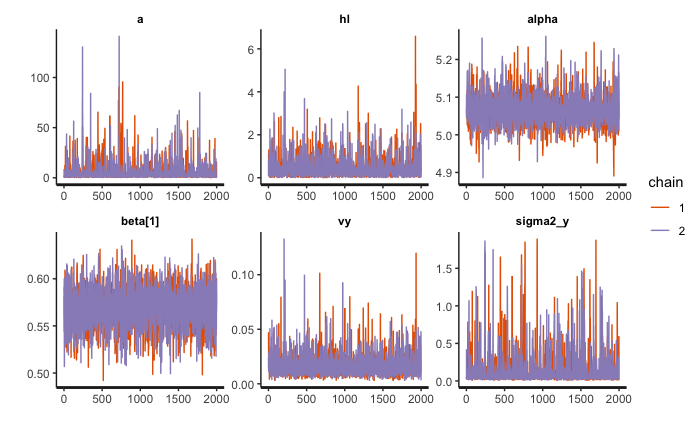

```r
par(mfrow = c(1,3))

traceplot(fit.fos.direct,c("a","hl","alpha","beta","vy","sigma2_y"))
```

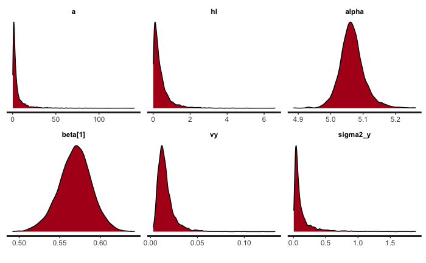

```r
stan_dens(fit.fos.direct,c("a","hl","alpha","beta","vy","sigma2_y"))
```

```r
#3 X 8
```

Make plots for Figure

```r
library(ggsci)
library(ggplot2)
library(plotly)
```

Classical Regression

```r
old.par <- par(mar = c(0, 0, 0, 0))
par(old.par)

fos.index<-which(ruminant.trdata$dat$Status=="Extinct")
print(paste("Fossil Species #",fos.index))
```

```
[1] "Fossil Species # 1"
```

```r
extant.index<-which(ruminant.trdata$dat$Status=="Extant")

body.predictions<-apply(posterior.fit.fos.direct$X_pred_fos_means,2,mean)
body.predictions.extant<-apply(posterior.fit.fos.direct$X_pred_extant_means,2,mean)

extant.data<-data.frame(Genus_Species = ruminant.trdata$phy$tip.label[-fos.index],log_brain = ruminant.trdata$dat$brain_mass_g_log_mean[-fos.index],log_body_pred = body.predictions.extant,log_body = ruminant.trdata$dat$bodycentered[-fos.index],Status="Extant")

fos.predictions<-data.frame(Genus_Species = ruminant.trdata$phy$tip.label[fos.index],log_brain = ruminant.trdata$dat$brain_mass_g_log_mean[fos.index], log_body_pred = body.predictions[fos.index],log_body=NA,Status="Extinct")

merged.data<-rbind(extant.data,fos.predictions)
```

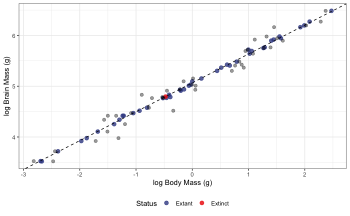

```r
brbo.plot<-ggplot(merged.data,aes(y=log_brain))+
geom_point(aes(x=log_body_pred,color=Status),size=2.5,alpha=0.8)+
geom_point(aes(x=log_body),size=2.0,alpha=0.4)+
geom_abline(intercept=mean(posterior.fit.fos.direct$alpha),slope = mean(posterior.fit.fos.direct$beta),lty=2)+
theme_bw()+
theme(legend.position="bottom")+ #5X5
ylab("log Brain Mass (g)")+
  xlab("log Body Mass (g)")

#+theme(legend. position = "none")
brbo.plot+scale_color_aaas()
```

```r
#Export 5.25X5 PDF
```

# Inverse Regression

Here we will assign one taxa as the fossil species to be predicted, and use Inverse Regression to predict an unknown value based on the combination of phylogeny and allometry. Here we are regression Y - brain size on X body size, and then predicting a fossil Y based on its X.

Here we will assign one taxa as the fossil species to be predicted

```r
ruminant.trdata <- make.treedata(phy, neocortex,name_column="species")

ruminant.trdata<-filter(ruminant.trdata,!(is.na(brain_mass_g_log_mean)) & !(is.na(body_mass_g_log_mean)))
ruminant.trdata<-filter(ruminant.trdata,!(is.na(brain_se_squared)) & !(is.na(body_se_squared)))

ruminant.trdata #Full dataset
```

```
$phy

Phylogenetic tree with 43 tips and 42 internal nodes.

Tip labels:
  Antilocapra_americana, Addax_nasomaculatus, Aepyceros_melampus, Alcelaphus_buselaphus_buselaphus, Antidorcas_marsupialis, Antilope_cervicapra, ...
Node labels:
  MF, MF, MF, MF, MF, MF, ...

Rooted; includes branch lengths.

$dat
```

| brain_mass_g_log_mean | brain_se_squared | n_brain | body_mass_g_log_mean | body_se_squared | n_body | neocortex_area_mm2_log_mean | neocortex_se_squared | n_neocortex | diet |
| --- | --- | --- | --- | --- | --- | --- | --- | --- | --- |
| 4.795791 | 0.0109399018 | 1 | 10.985293 | 0.042611489 | 1 | 9.724565 | 0.0054186866 | 2 | MF |
| 5.302425 | 0.0054699509 | 2 | 11.637916 | 0.021305745 | 2 | 9.969274 | 0.0036124577 | 3 | MF |
| 5.152387 | 0.0009945365 | 11 | 10.947994 | 0.003873772 | 11 | 9.957203 | 0.0004926079 | 22 | MF |
| 5.693832 | 0.0021879804 | 5 | 11.879786 | 0.008522298 | 5 | 10.276531 | 0.0010837373 | 10 | Gr |
| 4.912034 | 0.0008415309 | 13 | 10.484431 | 0.003277807 | 13 | 9.720171 | 0.0008336441 | 13 | MF |
| 4.770685 | 0.0109399018 | 1 | 10.419301 | 0.042611489 | 1 | 9.615605 | 0.0054186866 | 2 | MF |
| 4.418841 | 0.0109399018 | 1 | 9.433484 | 0.042611489 | 1 | 8.836783 | 0.0054186866 | 2 | Br |
| 4.418204 | 0.0036466339 | 3 | 9.581309 | 0.021305745 | 2 | 8.892092 | 0.0018062289 | 6 | Br |
| 3.520064 | 0.0013674877 | 8 | 8.461336 | 0.005326436 | 8 | 8.277107 | 0.0006773358 | 16 | Br |
| 5.720312 | 0.0109399018 | 1 | 11.918391 | 0.042611489 | 1 | 10.264616 | 0.0054186866 | 2 | Gr |

[output cut: 33 more lines]

```r
ruminant.trdata$dat$Status<-"Extant" #Label all species as extant
ruminant.trdata$dat$Status[1]<-"Extinct" #Make one extinct
n.fos<-1

#Inverse Regression - Predicting Y using regression of Y on X
ruminant.trdata$dat$brain_mass_g_log_mean[1]<-0 #Assign this species fake body mass
ruminant.trdata$dat$brain_se_squared[1]<-0 #And ME

ruminant.extant.trdata<-filter(ruminant.trdata, (Status == "Extant")) #Only non-fossil species

#Mean Standardized based on whether fossil is included in dataset
ruminant.trdata$dat$bodycentered<-ruminant.trdata$dat$body_mass_g_log_mean-mean(ruminant.trdata$dat$body_mass_g_log_mean[-n.fos])
ruminant.extant.trdata$dat$bodycentered<-ruminant.extant.trdata$dat$body_mass_g_log_mean-mean(ruminant.extant.trdata$dat$body_mass_g_log_mean)
```

Rescale Tree to Height =1

```r
l.tree<-max(branching.times(ruminant.trdata$phy))
ruminant.trdata$phy$edge.length<-ruminant.trdata$phy$edge.length/l.tree ## rescale tree to height 1
max(branching.times(ruminant.trdata$phy))
```

```
[1] 1
```

```r
l.tree<-max(branching.times(ruminant.extant.trdata$phy))
ruminant.extant.trdata$phy$edge.length<-ruminant.extant.trdata$phy$edge.length/l.tree ## rescale tree to height 1
max(branching.times(ruminant.extant.trdata$phy))
```

```
[1] 1
```

Running Blouch Data Setup Function - 1st trait is adapting to 2

```r
source("/Users/markgrabowski/Documents/Academic/Research/Current Projects/blouch/R/R Functions/Blouch Setup Files/blouchOUPredict.setup.v1.R")

#names.traits<-c("brain_mass_g_log_mean","bodycentered","NA","NA") #With ME
names.traits<-c("brain_mass_g_log_mean","bodycentered","brain_se_squared","body_se_squared") #With ME

#Data must be logged before entry into blouch.setup
#names.traits = c(response, predictor, me.response, me.predictor) - classical = 0 for inverse regression
stan_data<-blouchOUPredict.setup.v1(ruminant.extant.trdata,ruminant.trdata,names.traits,classical=0)
```

```
[1] "Fossil Species # 1"
```

```r
stan_constraint_data<-stan_data[[1]]
stan_adaptive_data<-stan_data[[2]]
```

Constraint Model for Prediction

```r
#setwd("/Users/markgrabowski/Google Drive/Shared with Macbook/Current Projects/Blouch project/Stan Functions/blouch v1")
#stanc("/Users/markgrabowski/Google Drive/Shared with Macbook/Current Projects/Blouch project/Stan Functions/blouch v1/blouchOUPredict_test.stan")

setwd("/Users/markgrabowski/Documents/Academic/Research/Current Projects/blouch/R/R Functions/Blouch Functions")
stanc("/Users/markgrabowski/Documents/Academic/Research/Current Projects/blouch/R/R Functions/Blouch Functions/blouchOUPredict_test.stan")

#stan_model <- stan_model("blouchOUPredict_v1.stan")
stan_model <- stan_model("blouchOUPredict_test.stan")

#fit.direct<- stan(file = stan_model,data = stan_constraint_data,chains = 1,iter = 400,control=list(adapt_delta=0.95))
fit.fos.direct<- rstan::sampling(object = stan_model,data = stan_constraint_data,chains = 2,iter = 4000,control=list(adapt_delta=0.95),save_warmup=FALSE)
```

```r
print(fit.fos.direct,pars = c("a","hl","alpha","beta","r_squared","sigma2_y","RMSE","RMSE_mu","Y_pred_fos_means"))
```

```
Inference for Stan model: anon_model.
2 chains, each with iter=4000; warmup=2000; thin=1;
post-warmup draws per chain=2000, total post-warmup draws=4000.

                    mean se_mean   sd 2.5%  25%  50%  75% 97.5% n_eff Rhat
a                   5.37    0.23 7.82 0.36 1.36 2.73 5.83 29.76  1174    1
hl                  0.43    0.01 0.62 0.02 0.12 0.25 0.51  1.91  1878    1
alpha               5.07    0.00 0.04 4.99 5.04 5.06 5.09  5.15  1781    1
beta[1]             0.57    0.00 0.02 0.53 0.56 0.57 0.58  0.61  2083    1
r_squared           0.96    0.00 0.00 0.95 0.96 0.96 0.97  0.97  1254    1
sigma2_y            0.14    0.01 0.20 0.02 0.04 0.07 0.15  0.74  1072    1
RMSE                0.21    0.00 0.02 0.17 0.20 0.21 0.23  0.27  3094    1
RMSE_mu             0.15    0.00 0.01 0.15 0.15 0.15 0.16  0.18  1053    1
Y_pred_fos_means[1] 5.09    0.00 0.13 4.85 5.01 5.09 5.17  5.35  3536    1

Samples were drawn using NUTS(diag_e) at Mon Nov 29 17:30:58 2021.
For each parameter, n_eff is a crude measure of effective sample size,
and Rhat is the potential scale reduction factor on split chains (at
convergence, Rhat=1).
```

```r
posterior.fit.fos.direct <- rstan::extract(fit.fos.direct)
```

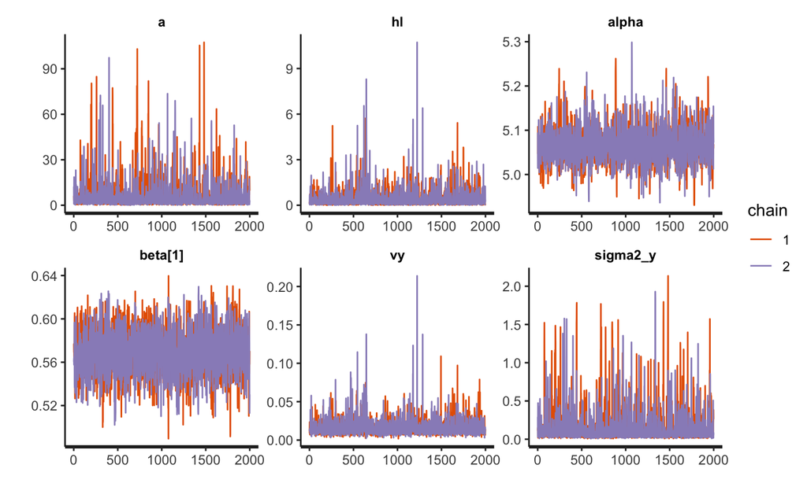

```r
par(mfrow = c(1,3))

traceplot(fit.fos.direct,c("a","hl","alpha","beta","vy","sigma2_y"))
```

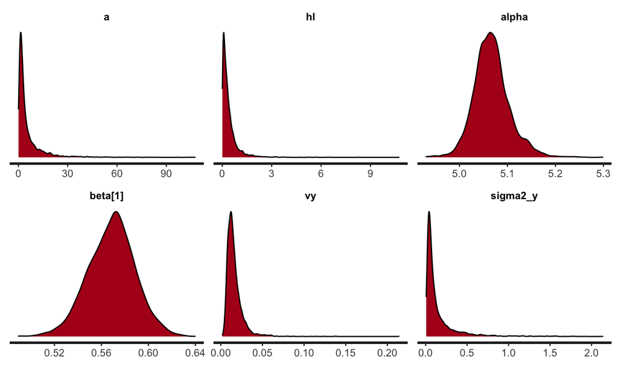

```r
stan_dens(fit.fos.direct,c("a","hl","alpha","beta","vy","sigma2_y"))
```

```r
#3 X 8
```

Make plots for Figure

```r
library(ggsci)
library(ggplot2)
library(plotly)
```

Plot including predictions for extant species SI HW Prediction Means - 5X5 pdf Inverse Regression

Inverse Regression

```r
old.par <- par(mar = c(0, 0, 0, 0))
par(old.par)

fos.index<-which(ruminant.trdata$dat$Status=="Extinct")
print(paste("Fossil Species #",fos.index))
```

```
[1] "Fossil Species # 1"
```

```r
extant.index<-which(ruminant.trdata$dat$Status=="Extant")

brain.predictions<-apply(posterior.fit.fos.direct$Y_pred_fos_means,2,mean)
brain.predictions.extant<-apply(posterior.fit.fos.direct$Y_pred_extant_means,2,mean)

extant.data<-data.frame(Genus_Species = ruminant.trdata$phy$tip.label[-fos.index],log_brain = ruminant.trdata$dat$brain_mass_g_log_mean[-fos.index],log_brain_pred = brain.predictions.extant,log_body = ruminant.trdata$dat$bodycentered[-fos.index],Status="Extant")

fos.predictions<-data.frame(Genus_Species = ruminant.trdata$phy$tip.label[fos.index], log_brain= ruminant.trdata$dat$brain_mass_g_log_mean[fos.index], log_brain_pred = brain.predictions[fos.index],log_body=ruminant.trdata$dat$bodycentered[fos.index],Status="Extinct")

merged.data<-rbind(extant.data,fos.predictions)
```

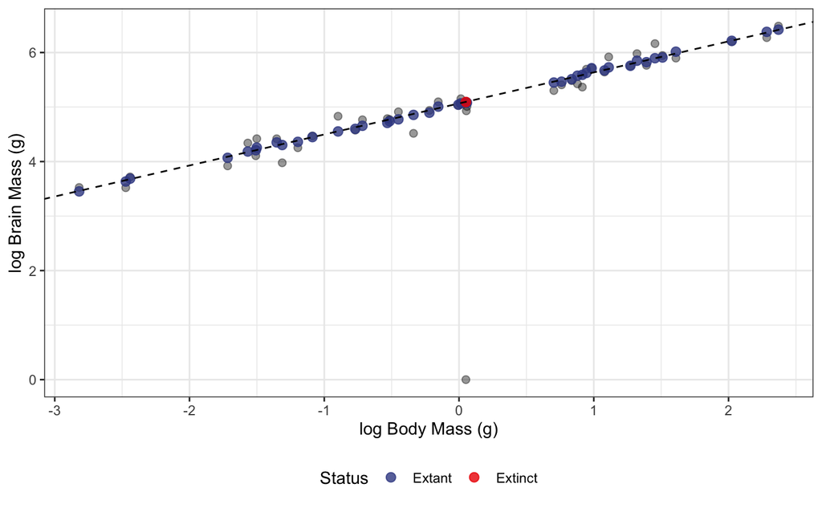

```r
brbo.plot<-ggplot(merged.data,aes(x=log_body))+
geom_point(aes(y=log_brain),size=2.0,alpha=0.4)+
geom_point(aes(y=log_brain_pred,color=Status),size=2.5,alpha=0.8)+
geom_abline(intercept=mean(posterior.fit.fos.direct$alpha),slope = mean(posterior.fit.fos.direct$beta),lty=2)+
theme_bw()+
theme(legend.position="bottom")+ #5X5
xlab("log Body Mass (g)")+
  ylab("log Brain Mass (g)")

#+theme(legend. position = "none")
brbo.plot+scale_color_aaas()
```

```r
#Export 5.25X5 PDF
```

Slouch Results for Comparison Adaptation model

```r
#OU Model of Evolution
slouch.OU<-slouch.fit(phy = ruminant.trdata$phy,
                              species = ruminant.trdata$phy$tip.label,
                              response = ruminant.trdata$dat$neocortex_area_mm2_log_mean,
                              random.cov = ruminant.trdata$dat$braincentered,
                              #mv.response = ruminant.trdata$dat$neocortex_se_squared,
                              #mv.random.cov = ruminant.trdata$dat$brain_se_squared,
                              hl_values = seq(0.00001, 0.3, length.out = 50),
                              vy_values = seq(0.00001, 0.1, length.out = 50),
                              hillclimb = TRUE,convergence = 150,
                              lower = c(0.00001, 0.00001)

                       )
summary(slouch.OU)
```

Adaptation model - w/ ME

```r
#OU Model of Evolution
slouch.OU<-slouch.fit(phy = ruminant.trdata$phy,
                              species = ruminant.trdata$phy$tip.label,
                              response = ruminant.trdata$dat$neocortex_area_mm2_log_mean,
                              random.cov = ruminant.trdata$dat$braincentered,
                              mv.response = ruminant.trdata$dat$neocortex_se_squared,
                              mv.random.cov = ruminant.trdata$dat$brain_se_squared,
                              hl_values = seq(0.00001, 0.2, length.out = 50),
                              vy_values = seq(0.00001, 0.1, length.out = 50),
                              hillclimb = TRUE,convergence = 150,
                              lower = c(0.00001, 0.00001)

                       )
summary(slouch.OU)
```

Constraint Model

```
Important - Always inspect the likelihood surface of the model parameters with
          grid search before evaluating model fit & results.

  Maximum-likelihood estimates
                       Estimate
Phylogenetic half-life 0.8173349
Stationary variance    0.05102939

  Inferred maximum-likelihood parameters
                                    Value
Mean phylogenetic correction factor 0.3258076
Rate of adaptation                  0.8480577
Diffusion variance                  0.08655173

  Interval of parameters in 3d plot (Sensitive to grid mesh, grid size and local ML estimate)
                          Minimum   Maximum
Phylogenetic half-life 0.10205061 5.0000000
Stationary variance    0.02041776 0.3775535

  Intercepts
            Estimates Std. error
(Intercept)  9.631766 0.08688529

  Direct-effect slope
                                  Estimates Std. error
ruminant.trdata$dat$braincentered 0.8440606 0.04301563

  Attenuation factor. Linear model coefficients (above) are not corrected for bias.

(Intercept)                       1 0.00285
ruminant.trdata$dat$braincentered 0 1.01000

  Model fit summary
            Values
Support    -29.600
AIC         67.300
AICc        68.300
SIC         74.300
R squared    0.756
SST        509.000
SSE        124.000
N (params)   4.000
```

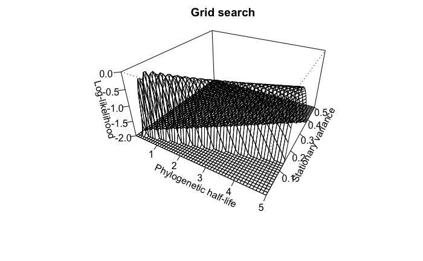

```r
#OU Model of Evolution
slouch.OU<-slouch.fit(phy = ruminant.trdata$phy,
                              species = ruminant.trdata$phy$tip.label,
                              response = ruminant.trdata$dat$neocortex_area_mm2_log_mean,
                              direct.cov = ruminant.trdata$dat$braincentered,
                              mv.response = ruminant.trdata$dat$neocortex_se_squared,
                              mv.direct.cov = ruminant.trdata$dat$brain_se_squared,
                              hl_values = seq(0.00001, 5, length.out = 50),
                              vy_values = seq(0.00001, 0.5, length.out = 50),
                              hillclimb = TRUE,convergence = 150,
                              lower = c(0.00001, 0.00001)

                       )
summary(slouch.OU)
```

Constraint Model w/o ME

```r
slouch.OU<-slouch.fit(phy = ruminant.trdata$phy,
                              species = ruminant.trdata$phy$tip.label,
                              response = ruminant.trdata$dat$neocortex_area_mm2_log_mean,
                              direct.cov = ruminant.trdata$dat$braincentered,
                              #mv.response = ruminant.trdata$dat$neocortex_se_squared,
                              #mv.direct.cov = ruminant.trdata$dat$brain_se_squared,
                              hl_values = seq(0.00001, 5, length.out = 50),
                              vy_values = seq(0.00001, 0.5, length.out = 50),
                              hillclimb = TRUE,convergence = 150,
                              lower = c(0.00001, 0.00001)

                       )
summary(slouch.OU)
```